# Progetto di Fondamenti di Scienza dei Dati

## INTRODUZIONE

## Introduzione

Nella cronaca di questi ultimi 2 anni si è parlato molto di attacchi informatici, soprattutto di tipo ransomware con annesso data breach, e il loro numero è aumentato in tutti i settori mettendo così in luce lo scarso livello di sicurezza dei sistemi informatici(configurazione non corretta degli apparati, sistemi operativi e softwares non mantenuti aggiornati, non si sfruttano sistemi IDS, …).

## Descrizione dataset

Il datasets presi in considerazione sono 3 e trattano principalmete i data breach avvenuti tra il 2004 e il 2022:

- [link](https://espace.library.uq.edu.au/view/UQ:dfe5027) il quale contiene informazioni su data breach e ransomware tra il 2004 e l’inizio del 2020 raccolti dall’università del Queensland;
- [link](https://en.wikipedia.org/wiki/List_of_data_breaches), che è il risultato dello scrapping della pagina wikipedia;
- [link](https://docs.google.com/spreadsheets/d/1Je-YUdnhjQJO_13r8iTeRxpU2pBKuV6RVRHoYCgiMfg/edit#gid=322165570) spreadsheet online.

## FEATURES

Features dataset università queensland:

```
##  [1] "Year"
##  [2] "Organisation"
##  [3] "Critical Industry"
##  [4] "Organisation size"
##  [5] "Level of digital intensity"
##  [6] "Sector"
##  [7] "Country"
##  [8] "Cyber security role"
##  [9] "Cyber security frameworks"
## [10] "Education and awareness policy"
## [11] "Policy"
## [12] "Prevention, Detection and Recovery"
## [13] "Improper network segmentation"
## [14] "Inappropriate remote access"
## [15] "Absence of encryption"
```

[output cut: 26 more lines]

Features dataset ottenuto da scrapping di wikipedia:

```
## [1] "Entity"            "Year"              "Records"
## [4] "Organization type" "Method"
```

Feautures dataset ‘data_breaches_2018_update’:

```
##  [1] "Entity"           "alternative name" "story"            "YEAR"
##  [5] "records lost"     "ORGANISATION"     "METHOD OF LEAK"   "DATA SENSITIVITY"
##  [9] "1st source link"  "source name"
```

## DOMANDE

## Domande

1. Come sono cresciuti gli attacchi con il passare degli anni?
2. Qual’è il settore che è stato maggiormente colpito?
3. Com’è cresciuto il volume di dati esfiltrati con il passare del tempo?
4. Che relazione esite tra sistemi di sicurezza implementati e le conseguenze di tale attacco?

## Come sono cresciuti gli attacchi con il passare degli anni?

## Come sono cresciuti gli attacchi con il passare degli anni?

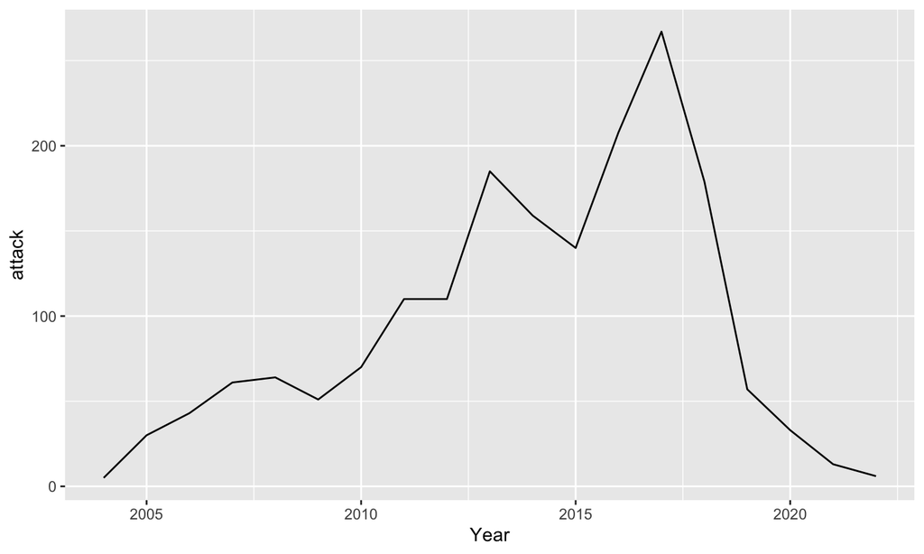

Dal grafico quà sopra si vede che fino al 2017 il numero di attacchi è aumentato fino a un numero di attacchi pari a 267 in un anno, per poi scendere negli anni successivi. Dal 2019 fino ad oggi c’è stata una riduzione non indifferente che probabilmete è stata portata da un aumento della sensibilizzazione da parte delle aziende nell’ambito della sicurezza e cybersecurity data anche per il fatto che con il COVID-19 ha portato molte aziende ad approcciarsi con lo smart working, necessitando di un maggior livello di sicurezza.

## Qual è il settore che è stato maggiormente colpito?

## Qual è il settore che è stato maggiormente colpito?

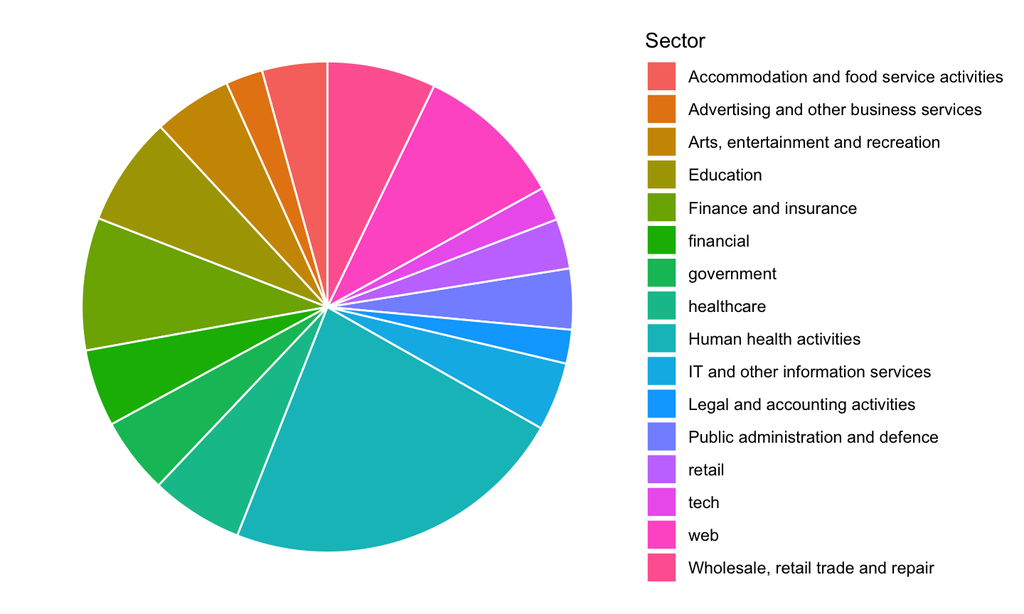

Da come viene mostrato dal grafico soprastante il settore che è stato maggiormente colpito è quello delle **Human health activities** con un totale di 318 attacchi il quale risulta più del doppio del settore subito sotto, che è quello del **web** con un totale di 137 attacchi dal 2004 al 2022.

## Perchè il settore *Human health activities* è quello maggiormente attaccato?

Analizzando i vari sistemi di sicurezza implemetati all’interno delle aziende che lavorano nel settore preso in considerazione, si ottengono i seguenti risultati

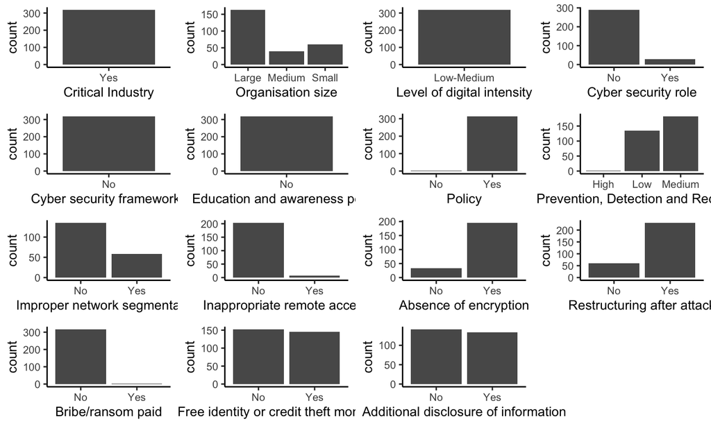

In generale a livello di sistemi di sicurezza ,il settore è messo abbastanza bene ma ci sono un paio di cose che saltano all’occhio:

- circa 200 aziende non usano la cifratura che è una possibile causa di un eventiuale pubblicazione dei dati esfiltrati illecitamete;
- non usano alcun cybersecurity framework il quale fornisce delle linee guida e le best practice per ottenere un sistema sicuro;
- nessuna di queste ha una politica di educazione e sensibilizzazione del personale che potrebbe essere la causa principale di questo numero spropositato di attacchi, quindi il fattore umano protrebbe essere una delle maggiori causa di attacco.

## Il fattore umano è davvero la causa principale di attacco nel settore?

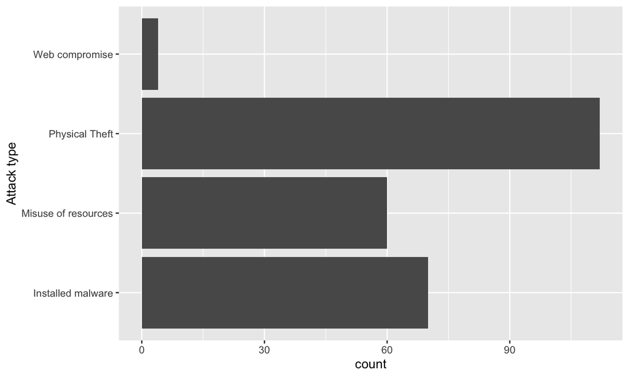

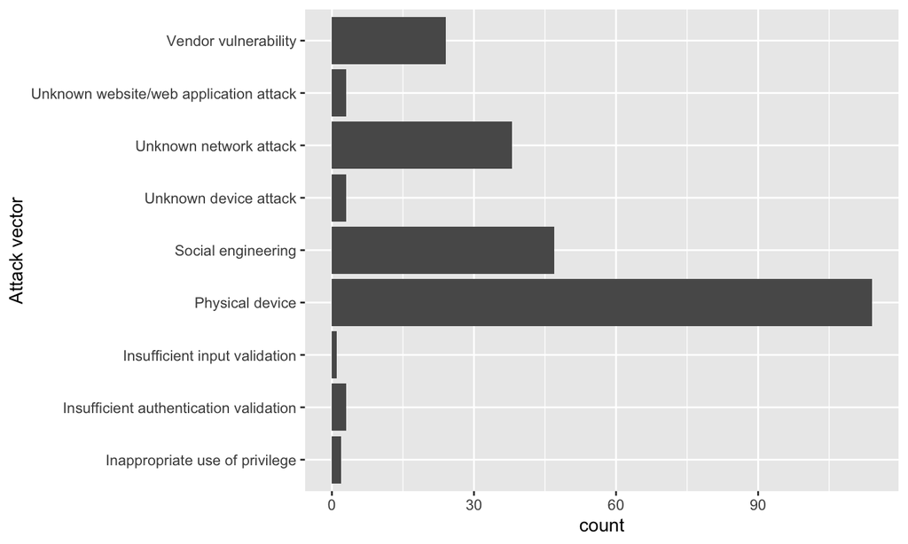

I grafici qua sopra dimostrana che il problema sta nel fattore umano, qundi nella mancanza di una corretta formazione e sensibilizzazione del personale su questi temi.

Infatti nella maggior parte dei casi l’attacco viene veicolato dai **device fisici** (periferiche infette, computer dei dipendenti infettati, …) a causa del loro furto, infatti, in secondo luogo, anche l’ **installazione di malware** è il tipo di attacco maggiormente utilizzato per attaccare il settore e ciò è dato dal fatto che molto spesso, l’installazione di malware e il furto di dispositivi fisici, o più in generale gli attacchi veicolati da essi, questi ultimi vengono usati come mezzo per iniziare l’infezione del sistema.

## Com’è cresciuto il volume di dati esfiltrati con il passare del tempo?

## Com’è cresciuto il volume di dati esfiltrati con il passare del tempo?

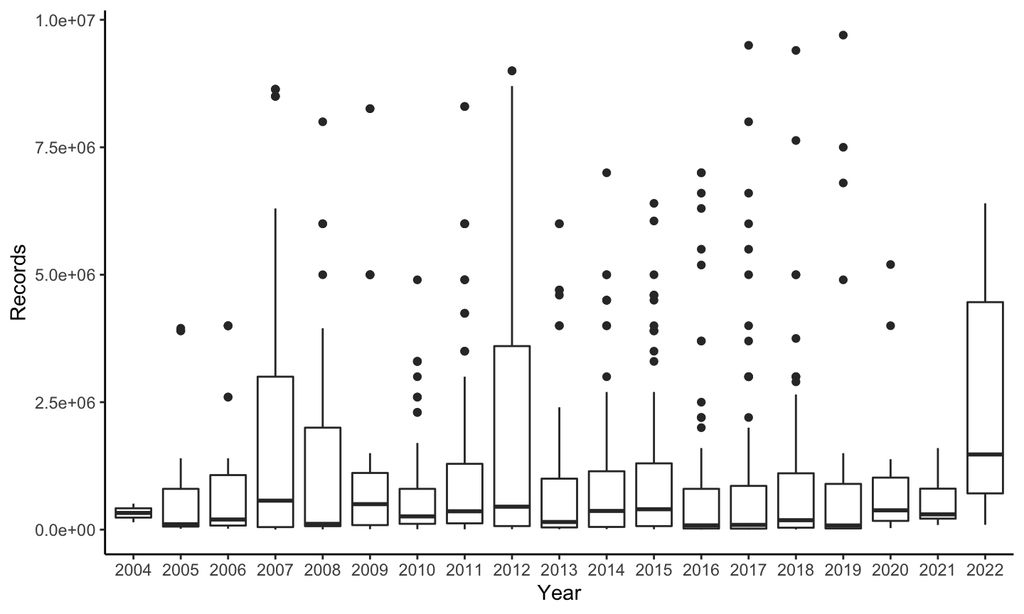

## Cosa influisce il volume di dati rubati?

Ora proviamo a vedere quale feature tra *dimensione dell’azienda*, *livello di digital intensity* e *sensibilità dei dati* vanno a influenzare il volume di dati rubati.

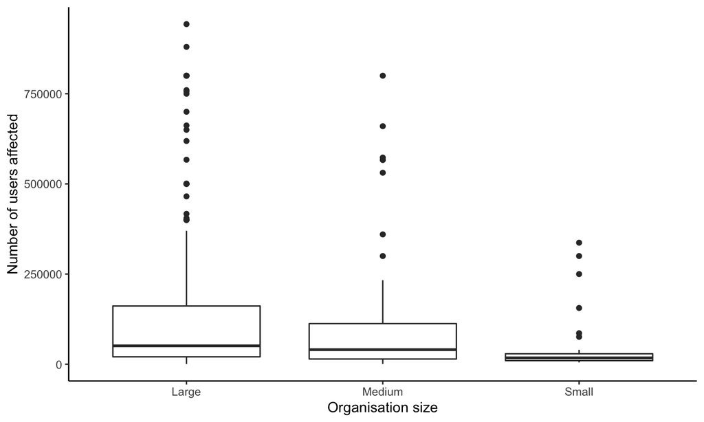

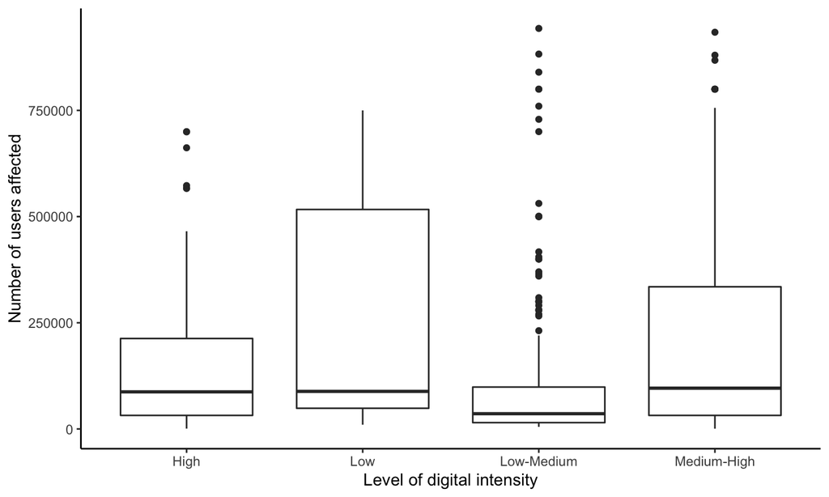

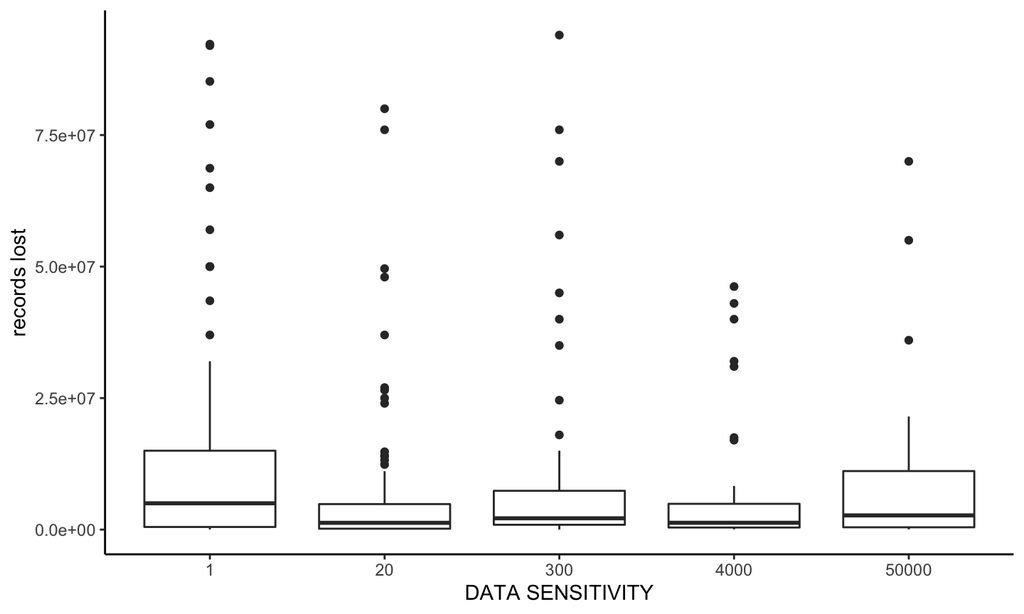

## Che relazione esite tra sistemi di sicurezza implementati e le conseguenze di tale attacco?

## Che relazione esite tra sistemi di sicurezza implementati e le conseguenze di tale attacco?

Per calcolare un possibile legame tra sistemi di sicurezza e conseguenze dell’attcco uso la **V di Cramer** la quale, in breve, è un indice per valutare la correlazione tra variabili categoriali (o qualitative) nominale.

\[ V = \sqrt {\frac{\chi ^ 2}{min(k-1, r-1)\cdot n}} \] dove χ<sup>2</sup> indica il **test chi quadro**, *n* indica le **osservazioni totali**, *k* indica il **numero di colonne** e *r* indica il **numero di righe**.

Il risultato è compreso tra **[0,1]**: con *0* si intende che tra le variabile non c’è alcuna correlazione e *1* indica che c’è un’alto livello di associazione, che può essere o positiva o negativa.

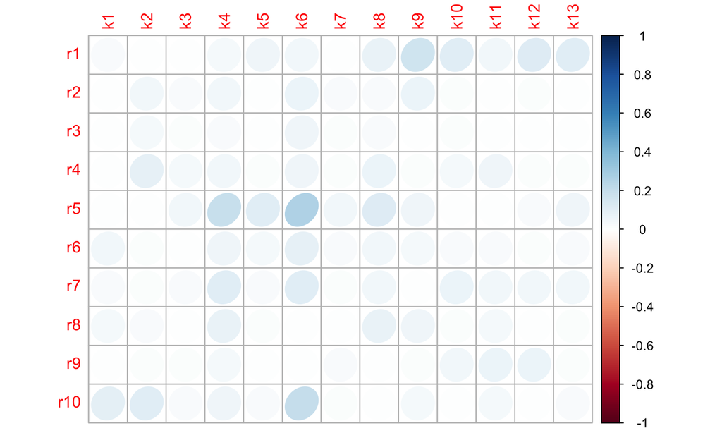

In linea generale non c’è alcuna correlazione forte tra sistemi di sicurezza e conseguenze dell’attacco tranne per alcuni casi:

- *r5 (Improper network segmentation)*-*k4 (Track1-Creadit card details leaked/exposed)*;
- *r5 (Improper network segmentation)*-*k6 (Social security number/tax number leaked/exposed)*;
- *r10 (Free identity or credit theft monitoring)*-*k6 (Social security number/tax number leaked/exposed)*.

Andiamo a commentare più nello specifico alcune caratteristiche di sicurezza come vanno a influire sulle conseguenze dell’attacco:

- **assenza di cifrature**

|  | Individual(s) name(s) leaked/exposed | Address(es) leaked/exposed | Other personally identifiable information (PII) leaked/exposed | Track 1 - Credit card details leaked/exposed | Track 2 - Credit card details leaked/exposed | Social security number/tax number leaked/exposed | Subsequent fraudulent use of data | Undertook investigation | Litigation by public | Penalties/settlement paid or actions imposed | Imposed penalties or actions on organisation | Fines issued by government or relevant body | Settlement paid |
| --- | --- | --- | --- | --- | --- | --- | --- | --- | --- | --- | --- | --- | --- |
| Absence of encryption | 0.02472 | 0.01234 | 0.02923 | 0.103 | 0.02481 | 0.108 | 0.01253 | 0.04126 | 0.008722 | 0.0641 | 0.04115 | 0.0428 | 0.04646 |

Se si tiene in considerazione l’assenza o meno della cifratura sembra non essere determinante per evitare un eventuale data leak di qualunque tipo o evitare di pagare o ricevere multe rilasciate direttamete dal governo oppure da enti competenti o qualunque altra azione imposta.

- **pagamento del riscatto**

|  | Individual(s) name(s) leaked/exposed | Address(es) leaked/exposed | Other personally identifiable information (PII) leaked/exposed | Track 1 - Credit card details leaked/exposed | Track 2 - Credit card details leaked/exposed | Social security number/tax number leaked/exposed | Subsequent fraudulent use of data | Undertook investigation | Litigation by public | Penalties/settlement paid or actions imposed | Imposed penalties or actions on organisation | Fines issued by government or relevant body | Settlement paid |
| --- | --- | --- | --- | --- | --- | --- | --- | --- | --- | --- | --- | --- | --- |
| Bribe/ransom paid | 0.007944 | 0.01856 | 0.01297 | 0.03615 | 0.009823 | 0.008123 | 0.02373 | 0.003368 | 0.01392 | 0.04274 | 0.06935 | 0.06327 | 0.0102 |

Come ci si poteva aspettare, il pagamento del riscatto non assicura la non diffusione e la conseguente cancellazzione dei dati prelevati in modo illecito. Tale risultato dopo tutto era scontato per il fatto che l’accordo viene fatto con dei criminale di cui di base non ci si può fidare e non si ha nessun tipo di garanzia che mi assicura la cancellazione dei dati.

## CONCLUSIONI

## Conclusioni

In linea generale si può concludere che la sicurezza dei sistemi informatici deve partire dal minimizzare i rischi portati dal **fattore umano** con una buona campagna di sensibilizzazione ed educazione del personale su tali tematiche.